# HW1_Xiaoliang_Wang

wendyxwang

Thursday, January 15, 2015

This is BIOST/STAT 578 A Homework 1 by Xiaoliang(Wendy) Wang

## Homework 1 Q3

Use the ggplot2 package to plot the Iris data showing length vs width facetting petal/sepal vs flower type, basically reproducing slide 27 of the lecture notes. Feel free to customize the styling as you see fit (color, font size, etc).

First, read in the data and see how the data is displayed.

```r
suppressMessages(library(sqldf))
data(iris)
head(iris)
```

```
##   Sepal.Length Sepal.Width Petal.Length Petal.Width Species
## 1          5.1         3.5          1.4         0.2  setosa
## 2          4.9         3.0          1.4         0.2  setosa
## 3          4.7         3.2          1.3         0.2  setosa
## 4          4.6         3.1          1.5         0.2  setosa
## 5          5.0         3.6          1.4         0.2  setosa
## 6          5.4         3.9          1.7         0.4  setosa
```

The Sepal/Petal is not a variable, so We need to reshape the data to allow facet wth two variables.

```r
library(reshape2)

iris$id<-rownames(iris)
#Use row numbers as flower id
iris_melted <- melt(iris)
head(iris_melted)
```

```
##   Species id     variable value
## 1  setosa  1 Sepal.Length   5.1
## 2  setosa  2 Sepal.Length   4.9
## 3  setosa  3 Sepal.Length   4.7
## 4  setosa  4 Sepal.Length   4.6
## 5  setosa  5 Sepal.Length   5.0
## 6  setosa  6 Sepal.Length   5.4
```

Then, we want to create new variable inditating sepal/petal of a flower

```r
#Split variable
split_type<-strsplit(as.character(iris_melted$variable), split = "\\.")
#Create two new variables
iris_melted$flower_part <- sapply(split_type, "[", 1)
iris_melted$measurement_type <- sapply(split_type, "[", 2)

head(iris_melted)
```

```
##   Species id     variable value flower_part measurement_type
## 1  setosa  1 Sepal.Length   5.1       Sepal           Length
## 2  setosa  2 Sepal.Length   4.9       Sepal           Length
## 3  setosa  3 Sepal.Length   4.7       Sepal           Length
## 4  setosa  4 Sepal.Length   4.6       Sepal           Length
## 5  setosa  5 Sepal.Length   5.0       Sepal           Length
## 6  setosa  6 Sepal.Length   5.4       Sepal           Length
```

We would want length and width in the same row for the same flower, so we use case function

```r
iris_cast<-dcast(iris_melted, formula = id + Species + flower_part ~ measurement_type)

head(iris_cast)
```

```
##    id    Species flower_part Length Width
## 1   1     setosa       Petal    1.4   0.2
## 2   1     setosa       Sepal    5.1   3.5
## 3  10     setosa       Petal    1.5   0.1
## 4  10     setosa       Sepal    4.9   3.1
## 5 100 versicolor       Petal    4.1   1.3
## 6 100 versicolor       Sepal    5.7   2.8
```

Now, we can use ggplot2 to plot length vs. width facetting sepal/petal vs. flower types to reproduce the plot on slide 27

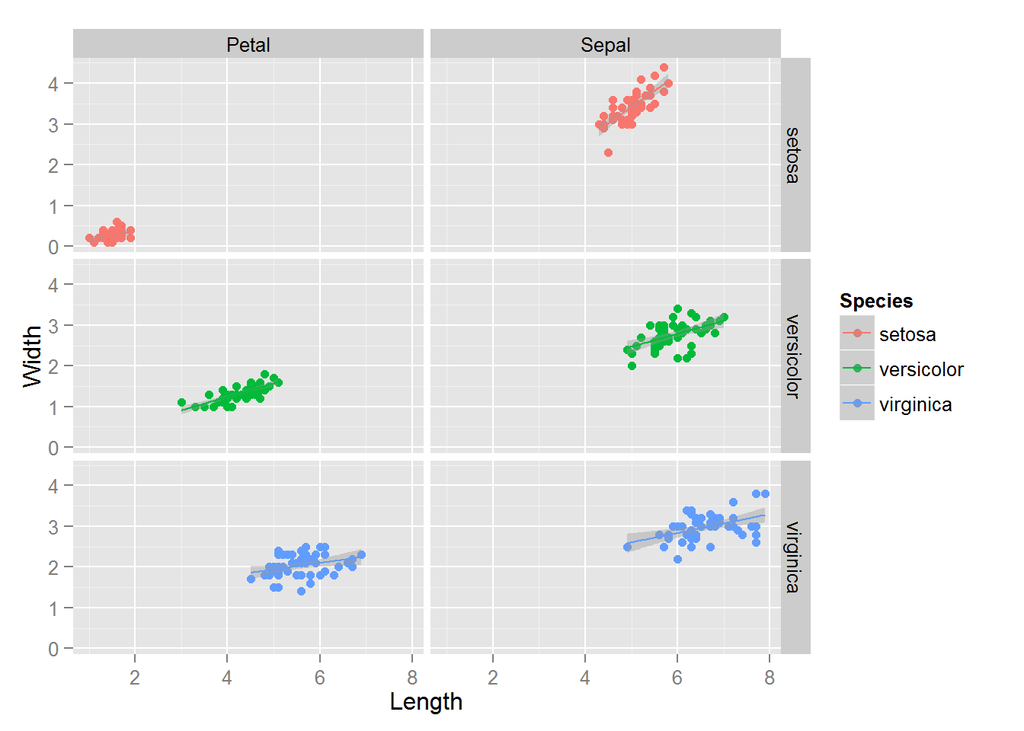

```r
library(ggplot2)

iris_plota <- qplot(x = Length, y = Width, data = iris_cast, geom = c("point", "smooth"), color = Species, method = "lm", facets = Species ~ flower_part)
iris_plota
```

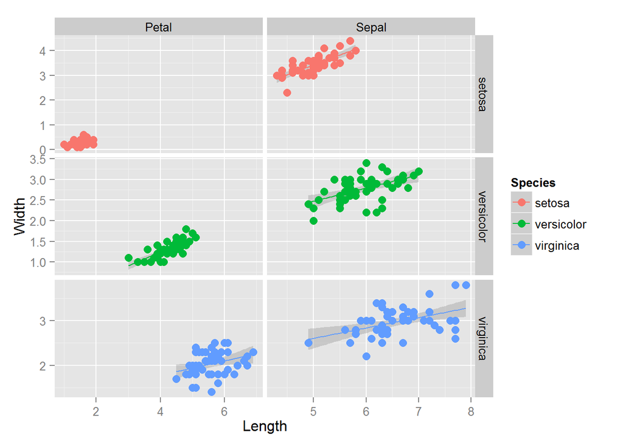

```r
#make the points larger and re-scale the plot
iris_plotb <- iris_plota + geom_point(size = 3) + facet_grid(Species ~ flower_part, scale = "free")
iris_plotb
```

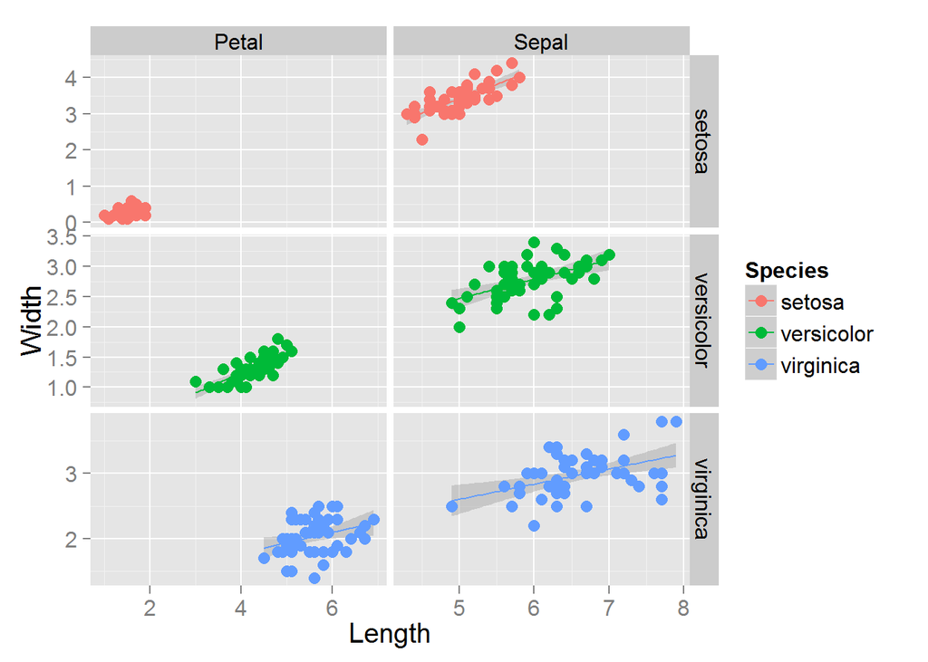

```r
#Looks better. But we would like to change font size larger
iris_plotc <- iris_plotb + theme(text = element_text(size = 15))
iris_plotc
```

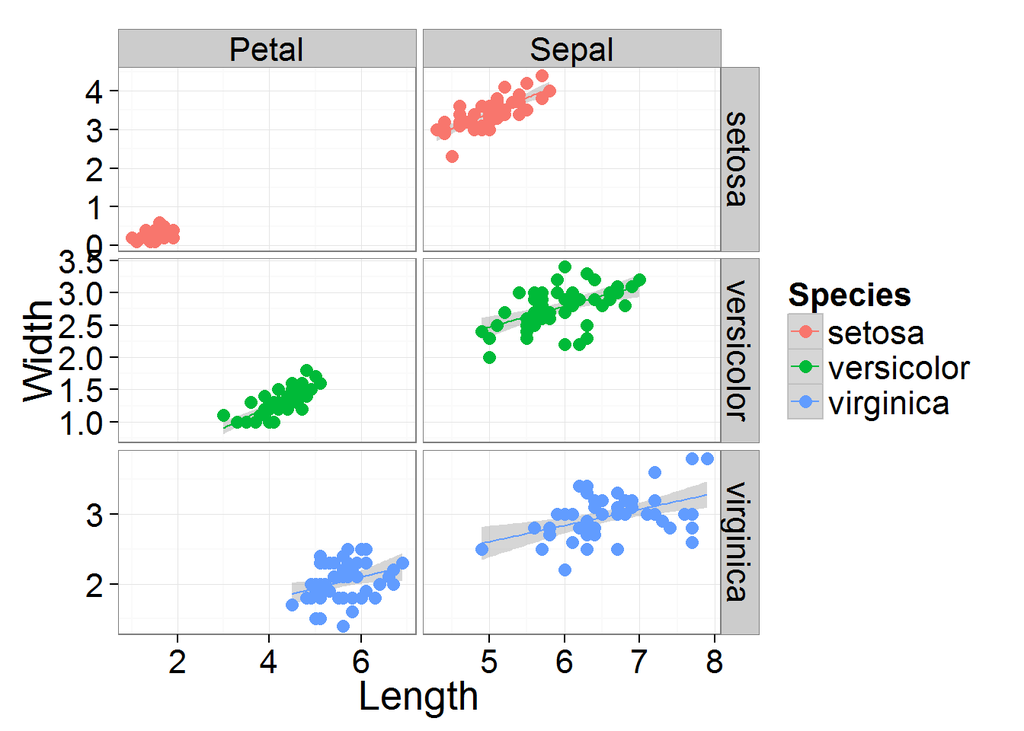

```r
#Looks good! now change the theme color to black and white and increase the base size a bit more
iris_plotd <- iris_plotc + theme_bw(base_size = 20)
iris_plotd
```

I like the last plot better than the one on slide 27. So, I will go with this one.

# Reference

The above code referred to Dr. Gottardo’s code in class

This work is licensed under a [Creative Commons Attribution-ShareAlike 4.0 International License](http://creativecommons.org/licenses/by-sa/4.0/).